# Fund Family Review

Review performance and flows of an entire fund family. Dodge & Cox, in this notebook.

Use tidyquant framework

```r
library(devtools)
#devtools::install_github("business-science/tidyquant")
#devtools::install_github("business-science/tibbletime")
library(broom)
library(stringr)
library(Rblpapi)
library(knitr)
library(tidyverse)
library(scales)
library(reshape2)
library(PerformanceAnalytics)
library(ggrepel)
library(mFilter)
library(tidyquant)
library(tibbletime)
options(scipen = 999)
source("utilities.r")
```

# Get the tickers of the relevant funds.

This section will vary depending on the ticker source. If you scrape the web site of the fund complex, each site will have a different layout. Parsing HTML is a dark art which I accomplish through frustrating trial and error. It does have the advantage of being self-contained within the R script.

Type FSRC into the Bloomberg terminal. Type “Investment Advisor” into the screening criteria box. Click “Update.” Select “Include/Exclude” Type the name of the desired fund company and choose from the dropdown list and hit return. Click on “Results.” Click on “Output” and select “Excel” Excel will load the file. Save as a csv file. “dodgecoxtickers.csv” in this example.

```r
dodgecoxtickers <- read_csv("dodgecoxtickers.csv")
secs<-dodgecoxtickers$ticker
```

# Retrieve fund info and performance rankings.

Note we get most of the data elements in a single `tq_get/bdp` call but multiple time periods at once for `PEER RANKING` is not possible. We want `PEER RANKING` fields for both three and five years, and the field name is the same, but the overrides change. I don’t know of a way to call multiple exclusive overrides at once.

```r
yearsAgo=10
#last day of the month preceeding the last full month yearsAgo
START_DATE=as.Date(as.yearmon(Sys.Date())-yearsAgo-1/12)-1

blpConnect()

# Get BBG Descriptive Data

Funds1<-tq_get(secs,get="rblpapi",rblpapi_fun="bdp",
       fields=c("NAME",
                "FUND_TOTAL_ASSETS",
                "FUND_BENCHMARK_PRIM",
                "FUND_MGR_STATED_FEE",
                "FUND_EXPENSE_RATIO",
                "DVD_FREQ",
                "CURRENT_ANN_TRR_3YR",
                "CURRENT_ANN_TRR_5YR"
                )
)


fund3yrRank<-tq_get(secs,get="rblpapi",rblpapi_fun="bdp",
                    fields="PEER_RANKING",
                    overrides=c("PEER_RANKING_PERIOD"='3Y')) %>%
  mutate(PEER_RANKING=100-PEER_RANKING) %>%
  rename(peer_rank_3Y=PEER_RANKING)

fund5yrRank<-tq_get(secs,get="rblpapi",rblpapi_fun="bdp",
                    fields="PEER_RANKING",
                    overrides=c("PEER_RANKING_PERIOD"='5Y')) %>%
  mutate(PEER_RANKING=100-PEER_RANKING) %>%
  rename(peer_rank_5Y=PEER_RANKING)
```

# Assemble fund meta data.

```r
#---------------------------------------------------
Funds<-left_join(Funds1,fund3yrRank,by="symbol") %>% left_join(fund5yrRank,by="symbol")
# clean up names
Funds<-Funds %>% rename(name=NAME,
                AUM=FUND_TOTAL_ASSETS,
                Benchmark=FUND_BENCHMARK_PRIM,
                Fee=FUND_MGR_STATED_FEE,
                Expense=FUND_EXPENSE_RATIO,
                DvdFreq=DVD_FREQ,
                Ret_3y=CURRENT_ANN_TRR_3YR,
                Ret_5y=CURRENT_ANN_TRR_5YR)
Funds<-Funds %>% separate(symbol,into=c("ticker","Domicile","sec_type"),remove=F)
#we don't distinguish share classes in this analysis so strip from names
shareClasses<-"(-A|-B|-C|-I|-R|-IS|-IV|-INV|-INST|-INS|-A1|-B2|-Y|-AUC|-E|-AU2)$"
Funds<-Funds %>% mutate(name=str_replace(name,shareClasses,"")%>%str_to_title())
#Save some space by removing company name from front of names
#We have to scan the name field to see all the variations of the company name
mgrID<-'Dodge & Cox |Dodge Cox-|Dodge&Cox |Dodge & Cox-'
Funds<-Funds %>% mutate(name=str_replace(name,mgrID,'D&C '))
#sort by AUM
Funds<-Funds[order(Funds$AUM,decreasing = T),]
#Empty benchmark changed to MXWO
#edit to change if you wish
Funds[Funds$Benchmark=="",]$Benchmark="MXWO"
raw_Funds<-as_data_frame(edit(Funds))
nrow(raw_Funds)
```

```
[1] 10
```

# Create the list of tickers for the funds and benchmarks.

For the purposes of this analysis let’s discard funds that are less than $1000mm in size.

```r
#Remove funds with less than $1bn in AUM
Funds<-filter(raw_Funds,AUM>1000)
#If needed, separate those funds that pay dividends monthly.  These are probably
#fixed income #funds. Many fixed income funds declare dividends daily and, for
#whatever reason, BBG will return NA for  DAY_TO_DAY_TOT_RETURN_GROSS_DVDS on
#any frequency longer than DAILY.
secs<-Funds$symbol
#create list of index tickers
ndxTicks<-Funds %>%
  filter(Benchmark!="") %>%
  transmute(Benchmark = paste(Benchmark,"INDEX")) %>%
  unique() %>%
  pull()
ndxTicks<-unique(c(ndxTicks,"LD12TRUU INDEX")) #don't add if it's already there
```

# Get historical benchmark return data.

```r
BBG_FIELDS=c('PX_LAST','DAY_TO_DAY_TOT_RETURN_GROSS_DVDS')
BDH_OPTIONS = c("periodicitySelection"="MONTHLY")
rawDataNdx <-ndxTicks %>%
  tq_get(get='rblpapi',
         rblpapi_fun='bdh',
         fields=BBG_FIELDS,
         start.date = START_DATE,
         end.date=Sys.Date(),
         options=BDH_OPTIONS
         ) %>%
  group_by(symbol)
```

Add wealth column and rename

```r
ndxRet<-rawDataNdx %>%
  rename(Value=PX_LAST,date=date) %>%
  mutate(return=DAY_TO_DAY_TOT_RETURN_GROSS_DVDS/100) %>%
  mutate(wealth=cumprod(1+return)) %>%
  separate(symbol,into="ticker",extra="drop") %>%
  mutate(name=ticker) %>%
  select(ticker,name,date,Value,return,wealth) %>%
  group_by(name)
head(ndxRet)
```

| ticker | name | date | Value | return | wealth |
| --- | --- | --- | --- | --- | --- |
| SPX | SPX | 2007-11-30 | 1481.14 | 0.000000 | 1.0000000 |
| SPX | SPX | 2007-12-31 | 1468.36 | -0.006969 | 0.9930310 |
| SPX | SPX | 2008-01-31 | 1378.55 | -0.059973 | 0.9334760 |
| SPX | SPX | 2008-02-29 | 1330.63 | -0.032455 | 0.9031800 |
| SPX | SPX | 2008-03-31 | 1322.70 | -0.004332 | 0.8992674 |
| SPX | SPX | 2008-04-30 | 1385.59 | 0.048686 | 0.9430491 |

# Get historical AUM and return data.

Get historical fund data. Use monthly frequency. For bond funds, dividends are often declared daily. In these cases we need to get daily frequency and convert to monthly returns ourselves. See note below.

```r
BBG_FIELDS=c('FUND_TOTAL_ASSETS','DAY_TO_DAY_TOT_RETURN_GROSS_DVDS')
BDH_OPTIONS = c("periodicitySelection"="MONTHLY")
rawData <-secs %>%
  tq_get(get='rblpapi',
         rblpapi_fun='bdh',
         fields=BBG_FIELDS,
         start.date = START_DATE,
         end.date=Sys.Date(),
         options=BDH_OPTIONS
         ) %>%
  group_by(symbol)
head(rawData)
```

| symbol | date | FUND_TOTAL_ASSETS | DAY_TO_DAY_TOT_RETURN_GROSS_DVDS |
| --- | --- | --- | --- |
| DODGX US Equity | 2007-11-30 | 65690.76 | 0.0000 |
| DODGX US Equity | 2007-12-31 | 63290.64 | -2.3762 |
| DODGX US Equity | 2008-01-31 | 58507.16 | -5.4463 |
| DODGX US Equity | 2008-02-29 | 56480.50 | -3.7941 |
| DODGX US Equity | 2008-03-31 | 54623.25 | -3.1740 |
| DODGX US Equity | 2008-04-30 | 58144.36 | 6.2254 |

Rename columns and create wealth series.

```r
aumret<-rawData %>%
  group_by(symbol) %>%
  mutate(date=date,
         AUM=na.approx(FUND_TOTAL_ASSETS,na.rm=F),
         return=na.fill(DAY_TO_DAY_TOT_RETURN_GROSS_DVDS/100,0)
  ) %>%
  mutate(wealth=cumprod(1+return)) %>%
  left_join(select(Funds,symbol,ticker,name),by='symbol') %>%
  group_by(name) %>%
  select(ticker,name,date,AUM,wealth,return)
head(aumret)
```

| ticker | name | date | AUM | wealth | return |
| --- | --- | --- | --- | --- | --- |
| DODGX | D&C Stock | 2007-11-30 | 65690.76 | 1.0000000 | 0.000000 |
| DODGX | D&C Stock | 2007-12-31 | 63290.64 | 0.9762380 | -0.023762 |
| DODGX | D&C Stock | 2008-01-31 | 58507.16 | 0.9230691 | -0.054463 |
| DODGX | D&C Stock | 2008-02-29 | 56480.50 | 0.8880470 | -0.037941 |
| DODGX | D&C Stock | 2008-03-31 | 54623.25 | 0.8598604 | -0.031740 |
| DODGX | D&C Stock | 2008-04-30 | 58144.36 | 0.9133901 | 0.062254 |

NOTE: Now convert everything to monthly? Not today. While not needed here some funds are on a daily accural schedule. In this case the monthly total returns from Bloomberg will be wrong. I typically flag those by testing for `DVD_FREQ='MONTHLY'`. In that case use `BDH_OPTIONS = c(“periodicitySelection”=“DAILY”)’ for return retrieval and then convert to monthly using the code below. Not needed here but it doesn’t hurt anything to run it.

```r
#Introduces tibbletime package
aumret<-aumret %>%
  as_tbl_time(index=date) %>%
  as_period(period="monthly",side="end",include_endpoints=F) %>%
  #rebuild return from wealth at monthly frequency
  mutate(return=na.fill(wealth/lag(wealth)-1,0)) %>%
  as_data_frame() #undo tibbletime
```

```
Note: Index not ordered. tibbletime assumes index is in ascending order. Results may not be as desired.
```

# Impute Flows

Next we can impute flows from the change in AUM net of return.

```r
#impute flows from change in AUM net of return
flows<-aumret %>%
  group_by(name) %>%
  mutate(flow=AUM-((1+return)*lag(AUM))) %>%
  mutate(flow=na.fill(flow,0)) %>%
  mutate(cum_flow=cumsum(flow))
#rm(aumret)
flows
```

| ticker | name | date | AUM | wealth | return | flow | cum_flow |
| --- | --- | --- | --- | --- | --- | --- | --- |
| DODGX | D&C Stock | 2007-11-30 | 65690.7600 | 1.0000000 | 0.000000 | 0.00000000 | 0.000000 |
| DODFX | D&C Intl Stck | 2007-11-30 | 53479.5200 | 1.0000000 | 0.000000 | 0.00000000 | 0.000000 |
| DODIX | D&C Income | 2007-11-30 | 15799.1400 | 1.0000000 | 0.000000 | 0.00000000 | 0.000000 |
| DODBX | D&C Balanced | 2007-11-30 | 27771.2000 | 1.0000000 | 0.000000 | 0.00000000 | 0.000000 |
| DODGX | D&C Stock | 2007-12-31 | 63290.6400 | 0.9762380 | -0.023762 | -839.17616088 | -839.176161 |
| DODFX | D&C Intl Stck | 2007-12-31 | 53479.0000 | 0.9939080 | -0.006092 | 325.27723584 | 325.277236 |
| DODIX | D&C Income | 2007-12-31 | 15932.3900 | 1.0003950 | 0.000395 | 127.00933970 | 127.009340 |
| DODBX | D&C Balanced | 2007-12-31 | 26932.3700 | 0.9841290 | -0.015871 | -398.07328480 | -398.073285 |
| DODGX | D&C Stock | 2008-01-31 | 58507.1600 | 0.9230691 | -0.054463 | -1336.48187368 | -2175.658035 |
| DODFX | D&C Intl Stck | 2008-01-31 | 49811.0600 | 0.9137821 | -0.080617 | 643.37654300 | 968.653779 |

[output cut: 692 more lines]

# Family Assets Under Management

What does mutual fund AUM look like?

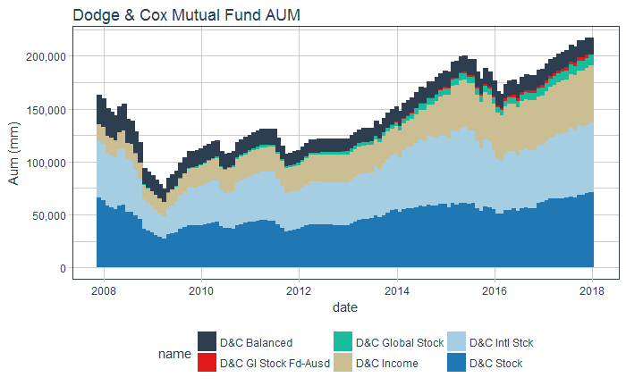

```r
gg<-flows %>%
  ggplot(aes(x=date,y=AUM,fill=name))+geom_col(width=40)
gg<- gg + ggtitle('Dodge & Cox Mutual Fund AUM')+
  xlab("date")+
  ylab('Aum (mm)')+
  scale_y_continuous(label=comma)+
    theme_tq()+
    scale_fill_tq()
gg
```

# Family Flows

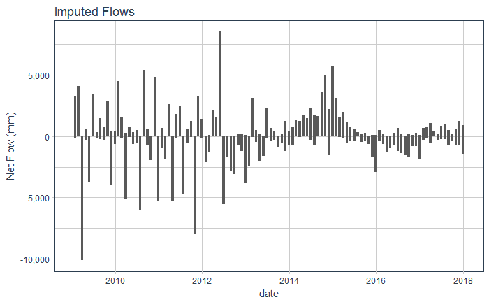

```r
gg<-flows %>%
  filter(date>as.Date("2009-01-01")) %>%
  ggplot(aes(date,flow))+geom_col(width = 20)
gg<- gg +ggtitle('Imputed Flows')+xlab("date")+ylab('Net Flow (mm)')+
    scale_y_continuous(label=comma)+
    theme_tq()+
    scale_color_tq()
gg
```

I don’t like the look of those monthly gyrations in 2010 but I can’t find any reason to suspect they are wrong.

# How do cumulative flows look?

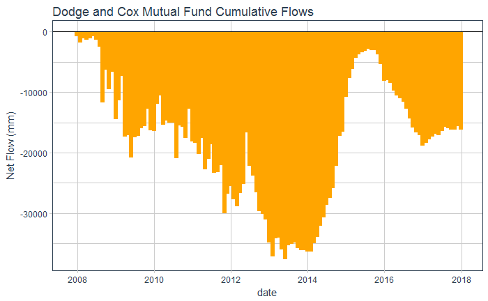

```r
#create cumulative
cum_flows<-flows %>% as_data_frame() %>%
  select(date,name,cum_flow) %>%
  spread(name,cum_flow) %>%
  {.}
cum_flows$Total<-cum_flows %>%
  select(-date) %>%
  apply(1,sum,na.rm=T)
gg<-  cum_flows %>%
  ggplot(aes(x=date, y=Total,fill="orange"))
gg<-gg<- gg +geom_col(width = 40)
gg<- gg + geom_abline(slope=0,intercept=0)
gg<- gg + ggtitle('Dodge and Cox Mutual Fund Cumulative Flows')+xlab("date")+ylab('Net Flow (mm)')
gg<-gg+scale_fill_manual(values = c("orange"),guide=FALSE)+
    theme_tq()
gg
```

# Look at annual flows.

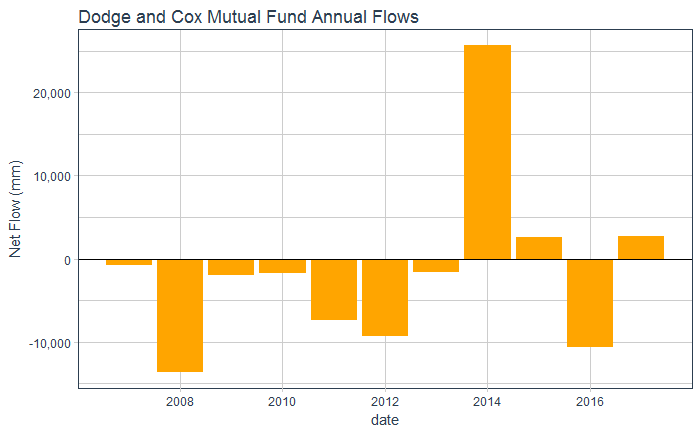

```r
annl_flow<-flows %>%
  mutate(year=year(date)) %>%
  group_by(year) %>%
  summarise(NetFlow=sum(flow))
gg<-  annl_flow %>% ggplot(aes(x=year, y=NetFlow,fill='orange')) +geom_col()
gg<- gg + geom_abline(slope=0,intercept=0)
gg<- gg + ggtitle('Dodge and Cox Mutual Fund Annual Flows')+xlab("date")+ylab('Net Flow (mm)')
gg<-gg+scale_fill_manual(values = c("orange"),guide=FALSE)+
    scale_y_continuous(label=comma)+
    theme_tq()
gg
```

Dodge and Cox has been struggling with tepid, varying flows marked by the banner year of 2014, when International Stock and Income Fund took off.

# Look at individual funds.

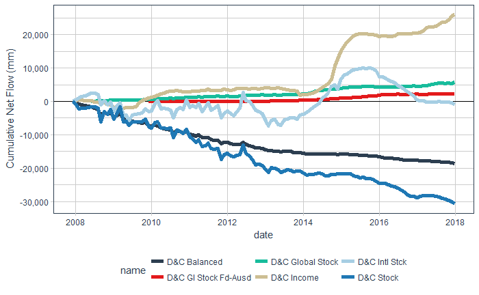

```r
flows %>% ungroup() %>%
  group_by(ticker) %>%
  ggplot(aes(x=date,y=cum_flow,color=name))+ geom_line()+
  geom_hline(yintercept = 1,linetype=1)+
  scale_y_continuous(label=comma)+
  labs(y="Cumulative Net Flow (mm)")+
    theme_tq()+
    scale_color_tq()+
    geom_line(size=2)
```

What are the top flow gainers and losers since the financial crisis of 2008?

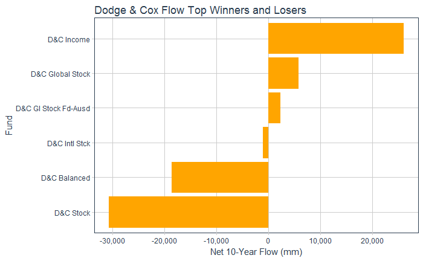

```r
sum_flows<-flows %>% group_by(name) %>% summarize(cum_flow=sum(flow))
sum_flows$name<-factor(sum_flows$name,
                       levels = sum_flows$name[order(sum_flows$cum_flow,decreasing = F)])
gg<-ggplot(sum_flows,aes(x=name,y=cum_flow))+geom_col(fill="orange")
gg<- gg +ggtitle('Dodge & Cox Flow Top Winners and Losers')+
  ylab('Net 10-Year Flow (mm)')+
  xlab('Fund')+
  coord_flip()+
  scale_y_continuous(label=comma)+
    theme_tq()
gg
```

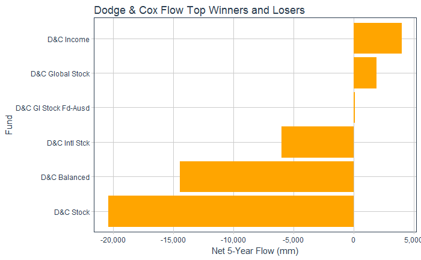

```r
sum_flows<-flows %>%
  filter(date<Sys.Date()-(365.25*5)) %>%
  group_by(name) %>%
  summarize(cum_flow=sum(flow))
sum_flows$name<-factor(sum_flows$name,
                       levels = sum_flows$name[order(sum_flows$cum_flow,decreasing = F)])
gg<-ggplot(sum_flows,aes(x=name,y=cum_flow))+geom_col(fill="orange")
gg<- gg +ggtitle('Dodge & Cox Flow Top Winners and Losers')+
  ylab('Net 5-Year Flow (mm)')+
  xlab('Fund')+
  coord_flip()+
  scale_y_continuous(label=comma)+
    theme_tq()
gg
```

Ouch.

# Focus on the Biggest Fund

Interestingly, their biggest fund, Stock, has been in outflows. The fund is 5-Star, top decile performance over three years and the management team is long tenured. How does it look over time?

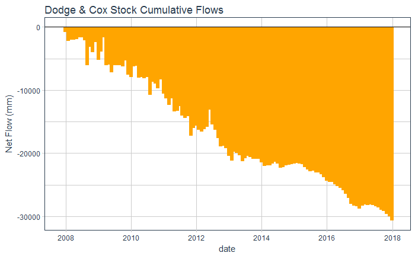

```r
gg<-flows %>%
  filter(ticker=='DODGX') %>%
  ggplot(aes(x=date,y=cum_flow))
gg<- gg+geom_col(fill='orange',width=40) #+geom_smooth()
#gg<- gg+geom_smooth()
gg<-gg+geom_abline(slope=0,intercept=0)
gg<- gg +ggtitle('Dodge & Cox Stock Cumulative Flows')+
  xlab("date")+ylab('Net Flow (mm)') +
  #scale_y_continuous(label=comma)+
  theme_tq()
gg
```

Steady outflows, despite a bull market since the crisis. How does performance vs. peers look?

```r
filter(Funds,ticker=='DODGX')%>%select(starts_with('Peer'))
```

| peer_rank_3Y | peer_rank_5Y |
| --- | --- |
| 6 | 2 |

Performance has been stellar of late vs. peers. How about vs. the benchmark, the S&P 500?

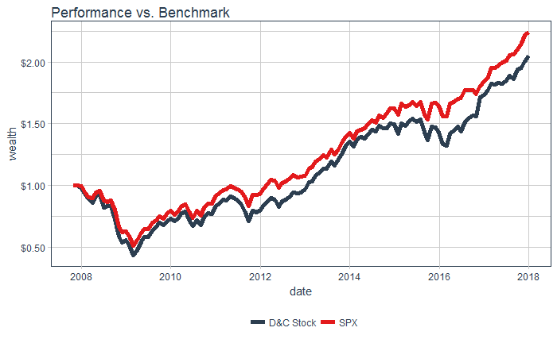

```r
# select fund benchmark and rebase.
fund<-'DODGX'
bench<-filter(Funds,ticker==fund)$Benchmark
temp<-bind_rows(filter(flows,ticker==fund),filter(ndxRet,name==bench))
gg<-chart_cum_returns(temp,
                        name_col='name',
                        ret_col='return',
                        date_col='date'
                        )
gg<-gg+
    geom_line(size=2)+
    theme_tq()+
    scale_color_tq()+
    scale_y_continuous(labels=dollar)+
    labs(x="date",y="wealth",title="Performance vs. Benchmark")+
    guides(col = guide_legend(title = NULL))
gg
```

Here we see the clue to the outflows. Great relative performance and a bull market are not enough to resist the onslaught of passive investing when the S&P500 is so strong. The S&P500 index has a strong growth stock bias. The fund has a value orientation and value has underperformed growth since the crisis.

Note I am using the benchmarks that Bloomberg has assigned. These might not be the most appropriate (Russell value might be better in this case) or the ones the fund company uses in the prospectus.

# Family Peer Group Rankings

Now let’s look at the broader complex. Bloomberg has it’s own peer group rankings. They are not going to be the same as Morningstar or Lipper but I have found they line up pretty closely. There may be some categories that don’t line up so compare before assuming for any specific fund.

First look at the distribution of quartile ranks by number of funds. A lower quartile number is better. Cool visualization.

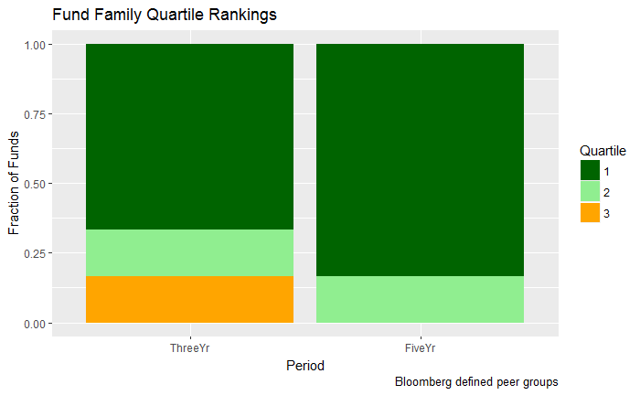

```r
#create quartile ranks
qr<-data_frame(name=Funds$name,
               AUM=Funds$AUM,
               ThreeYr=as.factor(trunc(Funds$peer_rank_3Y/100*4+1)),
               FiveYr=as.factor(trunc(Funds$peer_rank_5Y/100*4+1)))
#convert period columns into factors and get rid of funds with missing data
qr<-melt(qr,id=c('name','AUM'),
         measure.vars=c("ThreeYr","FiveYr"),
         variable.name = 'Period',value.name = "Quartile")%>%na.omit()
lb<-labs(title='Fund Family Quartile Rankings',
         x='Period',
         caption='Bloomberg defined peer groups')
ggplot(qr,aes(x=Period))+
  geom_bar(aes(weight=1/nrow(qr)*2,fill=Quartile))+lb+ylab("Fraction of Funds")+
  scale_y_continuous(labels=comma)+
  scale_fill_manual(values=c("DarkGreen","LightGreen","Orange","Red"))
```

```r
  #scale_fill_brewer(palette = "RdYlGn",direction=-1)
```

Now look at the distribution weighted by AUM. This perspective gives a better look at the experience of the typical investor.

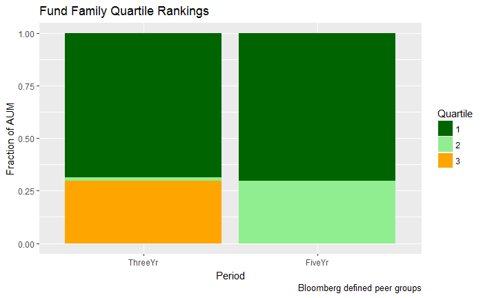

```r
ggplot(qr,aes(x=Period))+
  geom_bar(aes(weight=AUM/sum(AUM)*2,fill=Quartile))+lb+ylab("Fraction of AUM")+
  scale_y_continuous(labels=comma)+
  scale_fill_manual(values=c("DarkGreen","LightGreen","Orange","Red"))
```

Strong performance all around, with all their AUM in the top half on a 5-year basis, even the funds in heavy outflows.

# Performance vs. Benchmarks

Active managers are challenged to beat, not just their peers, but their index benchmarks. Let’s take a couple perspectives on that. First look at all the funds in our sample vs. their benchmarks. We we repeat the chart for D&C Stock already seen above.

It might be nice to turn these charts into a facet plot but adding two series per facet is a little tricky. Let’s try. We will create a data frame where the fund return and the benchmark return are two columns for each date. Do it by joining the fund returns to the Funds table which has the meta data including benchmark (this data frame is not completely tidy). Then join the result to the `ndx_ret` table for the index returns. Finally, rebase the wealth column to align with the start dates of the funds if they start after the start of the index data.

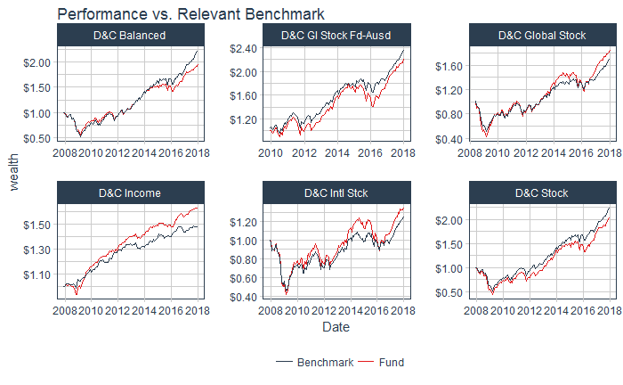

```r
#make a new frame with fund return and benchmark return in different columns
comp_ret<-flows %>% rename(fund_name=name,Ra=return,Wa=wealth) %>%
  left_join(select(Funds,ticker,Benchmark)) %>%
  left_join(rename(select(ndxRet,date,ticker,return,wealth),
                   Wb=wealth,
                   Benchmark=ticker)) %>%
  rename(Rb=return,benchmark=Benchmark) %>%
  select(date,ticker,fund_name,Ra,Wa,benchmark,Rb,Wb) %>%
  mutate(Wa=cumprod(1+Ra)) %>%
  mutate(Wb=cumprod(1+Rb))
#plot it facet style
comp_ret %>% ggplot(aes(date,Wa,group=fund_name,color="Fund"))+
  geom_line()+
  geom_line(aes(date,Wb,group=fund_name,color="Benchmark"))+
  guides(col = guide_legend(title = NULL))+
  scale_y_continuous(labels=dollar)+
  labs(x="Date",y="wealth",title="Performance vs. Relevant Benchmark")+
  theme_tq()+
  scale_color_tq()+
  facet_wrap(~fund_name, scale='free')
```

The client experience is not just about total return. Risk enters into it as well. In particular, downside protection is a key attribute advisors focus on (nobody complains about upside risk). Use the `UpDownRatios` function from the `performanceAnalytics` to measure this.

```r
CR<-comp_ret %>% tq_performance(Ra,Rb,performance_fun=UpDownRatios) %>%
  mutate(CaptureRatio=UpCapture/DownCapture)
kable(CR,digits=3)
```

| fund_name | DownCapture | DownNumber | DownPercent | UpCapture | UpNumber | UpPercent | CaptureRatio |
| --- | --- | --- | --- | --- | --- | --- | --- |
| D&C Stock | 1.205 | 0.950 | 0.325 | 1.113 | 0.877 | 0.630 | 0.924 |
| D&C Intl Stck | 1.061 | 0.912 | 0.351 | 1.100 | 0.922 | 0.578 | 1.037 |
| D&C Income | 0.681 | 0.659 | 0.732 | 1.027 | 0.875 | 0.462 | 1.508 |
| D&C Balanced | 0.877 | 0.975 | 0.675 | 0.858 | 0.914 | 0.284 | 0.978 |
| D&C Global Stock | 1.208 | 0.930 | 0.256 | 1.218 | 0.877 | 0.699 | 1.008 |
| D&C Gl Stock Fd-Ausd | 1.253 | 0.939 | 0.242 | 1.112 | 0.846 | 0.631 | 0.887 |

Now plot it on a fancy hand-rolled chart.

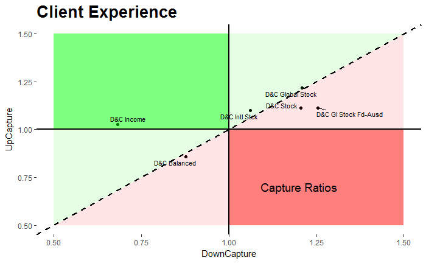

```r
#Do a fancy capture ratio chart
# define shaded regions
LIMIT_SCALE = FALSE
weakZone <- data.frame(x=c(0.5,1.0,1.0,1.5,1.5),y=c(0.5,0.5,1.0,1.0,1.5))
strongZone <- data.frame(x=c(0.5,0.5,1.0,1.0,1.5),y=c(0.5,1.0,1.0,1.5,1.5))
# plot using ggplot2
gg<-ggplot(CR,aes(DownCapture,UpCapture))+geom_point()
#gg<-gg+theme_classic()
# shaded backgrounds
gg<-gg+annotate("rect",xmin = 0.5,ymin=1,xmax=1,ymax = 1.5,fill='green',alpha=0.5)
gg<-gg+annotate("rect",xmin = 1,ymin=0.5,xmax=1.5,ymax = 1,fill='red',alpha=0.5)
gg<-gg+geom_polygon(data=weakZone,aes(x=x,y=y),fill='red',alpha=0.1)
gg<-gg+geom_polygon(data=strongZone,aes(x=x,y=y),fill='green',alpha=0.1)
gg<-gg+theme(panel.background = element_rect(fill = "white"))
# lines
gg<-gg+geom_abline(intercept = 0,slope = 1,color='black',size=1,linetype='dashed')
gg<-gg+geom_vline(xintercept = 1,color='black',size=1)
gg<-gg+geom_hline(yintercept = 1,color='black',size=1)
# Text elements. Make sure text labels don't overlap
gg<-gg + geom_text_repel(label=CR$fund_name,size=3)
gg<-gg+ggtitle('Client Experience')
gg<-gg+theme(plot.title=element_text(size=20,face='bold'))
# limit range. funds outside of range not plotted
if (LIMIT_SCALE) gg<-gg+xlim(c(0.5,1.5))+ylim(c(0.5,1.5))+coord_equal()
gg<-gg+annotate("text",x=1.2,y=0.7,label=paste('Capture Ratios'),size=5)
print(gg)
```

# Rolling Betas

Since we are working in the tidyverse, rather than zoo/xts for our time series, rollapply doesn’t work. Tidyquant doesn’t adapt the rolling functions of the `performanceAnalytics` package. Rather than convert our data frames to xts, the new tibbletime package has a function wrapper `rollify` that does the trick. Boy, does that save some line of code!

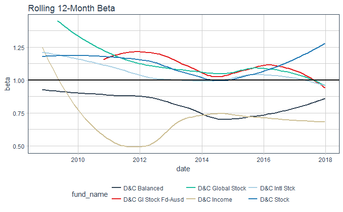

```r
# extract the y coefficient ("beta") from lm.
#use cool rollify function from tibble time.
beta_roll_12<-rollify(~lm(.x ~ .y)[[1]][[2]], window = 12)
comp_ret <-comp_ret %>% mutate(beta=beta_roll_12(Ra,Rb))
comp_ret %>%
  ggplot(aes(x=date,y=beta,color=fund_name))+
  geom_smooth(se=FALSE)+
  geom_hline(yintercept = 1,color='black',size=1)+
  ggtitle("Rolling 12-Month Beta")+
  theme_tq()+
  scale_color_tq()
```

Next we drill into some of the data. For the following tables and charts we use the PerformanceAnalytics package, which includes many investment return time series analysis functions.

Let’s look at the CAPM stats. We assume the risk free rate is 1.00%

```r
sr<-comp_ret %>%
  tq_performance(Ra = Ra, Rf=0.01/12,performance_fun = SharpeRatio.annualized)
names(sr)<-c("fund_name","Sharpe")
cagr<-comp_ret %>%
  tq_performance(Ra = Ra, performance_fun = Return.annualized)
capm<-comp_ret %>% tq_performance(
          Ra=Ra,
          Rb=Rb,
          Rf=0.01/12,
          scale=12,
          performance_fun = table.CAPM)
capm<-left_join(capm,sr,by='fund_name') %>%
  left_join(select(CR,'CaptureRatio')) %>%
  left_join(cagr)
# trick to transpose with column names
kable(capm %>% gather(Stat,val,-fund_name) %>% spread(fund_name,val),align='c',digits=3)
```

| Stat | D&C Balanced | D&C Gl Stock Fd-Ausd | D&C Global Stock | D&C Income | D&C Intl Stck | D&C Stock |
| --- | --- | --- | --- | --- | --- | --- |
| ActivePremium | -0.015 | -0.009 | 0.009 | 0.010 | 0.007 | -0.009 |
| Alpha | 0.000 | -0.002 | 0.000 | 0.001 | 0.001 | -0.001 |
| AnnualizedAlpha | -0.005 | -0.022 | 0.003 | 0.014 | 0.009 | -0.017 |
| AnnualizedReturn | 0.068 | 0.102 | 0.066 | 0.049 | 0.030 | 0.073 |
| Beta | 0.872 | 1.174 | 1.236 | 0.834 | 1.113 | 1.164 |
| Beta- | 0.896 | 1.099 | 1.267 | 0.934 | 1.112 | 1.176 |
| Beta+ | 0.845 | 1.196 | 1.333 | 0.741 | 1.226 | 1.145 |
| CaptureRatio | 0.978 | 0.887 | 1.008 | 1.508 | 1.037 | 0.924 |
| Correlation | 0.966 | 0.960 | 0.973 | 0.703 | 0.973 | 0.971 |
| Correlationp-value | 0.000 | 0.000 | 0.000 | 0.000 | 0.000 | 0.000 |
| InformationRatio | -0.367 | -0.185 | 0.146 | 0.346 | 0.142 | -0.189 |
| R-squared | 0.932 | 0.921 | 0.947 | 0.494 | 0.948 | 0.942 |
| Sharpe | 0.425 | 0.579 | 0.267 | 1.019 | 0.094 | 0.349 |
| TrackingError | 0.040 | 0.049 | 0.061 | 0.028 | 0.052 | 0.050 |
| TreynorRatio | 0.066 | 0.077 | 0.045 | 0.047 | 0.018 | 0.054 |

Finally, let’s look at a summary of canonical performance measures in a holistic way via a “spider chart.” We have taken a bunch of stats where higher is better and normalized them where “1” is the same as the benchmark. Note the absolute levels have varying and arbitrary meanings for the sake of easy visual comparison.

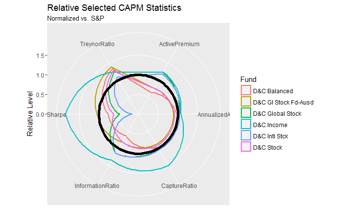

```r
spx_sharpe<-ndxRet %>% filter(name=="SPX") %>%
  tq_performance(Ra=return,performance_fun=SharpeRatio.annualized) %>% .[1,2] %>% pull()
ratios<-capm %>%
  select('ActivePremium',
         'AnnualizedAlpha',
         'InformationRatio',
         'TreynorRatio',
         'CaptureRatio',
         'Sharpe')
#The first four values are zero if performance is the same as the benchmark but set to "1" to visualize worse than benchmark performance
mag_factor<-5
ratio_norm<-ratios
ratio_norm <- ratio_norm %>% mutate(TreynorRatio=TreynorRatio*mag_factor)
ratio_norm <- ratio_norm %>% mutate(AnnualizedAlpha=AnnualizedAlpha*mag_factor)
ratio_norm <- ratio_norm %>% mutate(ActivePremium=ActivePremium*mag_factor)
ratio_norm <- ratio_norm %>% mutate(ActivePremium=ActivePremium*mag_factor)
ratio_norm <- ratio_norm %>% mutate_at(vars(1:4),funs(.+1))
ratio_norm <- ratio_norm %>% mutate(Sharpe=Sharpe/spx_sharpe)
#transpose and tidy for chart
ratio_norm<- ratio_norm %>%
  gather(name,value,-1) %>%
  rename(Fund=fund_name) %>%
  group_by(Fund) %>%
  arrange(Fund,name)
gg<- ggplot(ratio_norm,aes(x=name,y=value,group=Fund,color=Fund))+
  geom_polygon(size=1,fill=NA)
gg<-gg+ylim(c(0,max(ratio_norm$value)))
gg<-gg+ggtitle('Relative Selected CAPM Statistics',"Normalized vs. S&P")
gg<-gg+ylab('Relative Level')+xlab(NULL)
gg<-gg+geom_hline(yintercept = 1,size=2)
gg<-gg+coord_polar()
gg
```